# Continuation of Cleaning

Our semi-cleaned data of the roller-derby survey has been saved to a .xlsx file. Here, we will import it along with the necessary libraries.

```python
# necessary libraries
import pandas as pd
import numpy as np
import missingno as msno

# read cleaned survey data from last time
survey_data = pd.read_excel('/content/input.xlsx')
```

# Dropping Unwanted Columns

Recall that certain questions (variables) in the survey allowed an "other" option to which a text entry is then made available. In the tabular survey data, these questions had an adjacent column to handle this text entry, which was undesirable. Therefore it was chosen to map the text entry for entries of other to its question to the left, and delete the column.

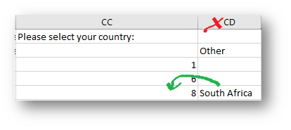

```python
# list of columns with an 'Other' column following them
other_selections = ['What is the role you most identify with regarding your local Roller Derby team?', \
          'Please select your country:', 'Which race/ethnicity/ancestry best describes you?']

# 'Other' columns
other_columns = ['Other', 'Other.1', 'Other.2'] # suffixes were added from saving the previous dataframe as an excel file

for i in range(3):
    # move text entry in 'Other' column to cell in its leftside column where other was selected
    survey_data.loc[survey_data[other_selections[i]] == survey_data[other_selections[i]].max(),\
                    other_selections[i]] = survey_data[other_columns[i]]
    # drop 'Other' column
    survey_data = survey_data.drop(columns=other_columns[i])
```

# Mapping to Text Data

You may have noticed the numerical entries in the "Please select your country:" variable from the image above. The column is now inconsistent due to the text data we moved. Note that these numbers map to a finite set of options:

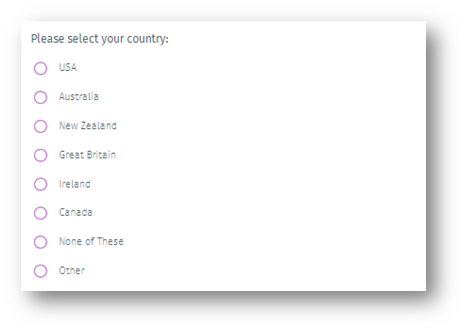

This is the case for almost all questions in the survey: the bubble that is selected maps the selection to its respective number as an option. Upon emailing Dr. Bradley, it was decided to map these numerical values to their text entry. This was done using a dictionary whose keys represented columns in need of mapping. The value to each key is another dictionary that holds the numerical value as the key and its text entry as the value. Looping through this dictionary, we successfully map all necessary values.

Lastly, a couple columns containing unnecessary data were dropped.

```python
# dictionary to map selection options into dataframe
map = {9:{1:'I am under the age of 18.', 2:'I do not want to participate in this survey.', \
              3:'I am at least 18 years of age and agree to participate in this survey.'},
           10:{1:'Player/Participant', 2:'Player With Leadership Role', 3:'Coach/Manager', 4:'Scorekeeper/Stats', 5:'First Aid/Safety', \
               6:'Referee/Official', 7:'Spectator/Fan/Supporter', 8:'Sponsor', 9:'Prefer Not To Answer', 10:'None of These'}, \
           14:{1:'Yes', 2:'No', 3:'Unsure', 4:'Prefer Not To Answer'}, \
           15:{1:'Roller derby is an activity I enjoy watching as a spectator.',\
               2:'It is an infrequent activity that is incidental to other activities.',\
               3:'It is an important but not exclusive recreation activity.',\
               4:'Roller derby is my primary recreation activity.'},\
           79:{1:'USA', 2:'Australia', 3:'New Zealand', 4:'Great Britain', 5:'Ireland', 6:'Canada', 7:'None of These'}, \
           80:{1:'US - American Indian or Alaska Native', 2:'US - Asian', 3:'US - Black or African American', 4:'US - Native Hawaiian or Other Pacific Islander',\
               5:'US - White', 6:'US - Hispanic/Latino/Spanish of Any Race', 7:'US - Mixed Race/Ethnicity/Ancestry', 8:'US - Prefer not to say',\
               9:'US - Other/Unknown', 10:'Canada - White', 11:'Canada - First Nations/Metis/Inuit', 12:'Canada - Asian', 13:'Canada - African/Caribbean/Black Canadian',\
               14:'Canada - Native Hawaiian or other Pacific Islander', 15:'Canada - Mixed Race/Ethnicity/Ancestry', 16:'Canada - Prefer not to say',\
               17:'Canada - Other/Unknown', 18:'Europe - English/British', 19:'Europe - Welsh', 20:'Europe - Scottish', 21:'Europe - Irish', 22:'Europe - Northern Irish',\
               23:'Europe - Gypsy/Traveler', 24:'Europe - Polish', 25:'Europe - Other White Background', 26:'Europe - White and Black Caribbean',\
               27:'Europe - White and Black African', 28:'Europe - White and Asian', 29:'Europe - Any other White Mixed/Multiple ethnic background',\
               30:'Europe - Indian', 31:'Europe - Pakistani', 32:'Europe - Bangladeshi', 33:'Europe - Chinese', 34:'Europe - Any other Asian background',
               35:'Europe - African', 36:'Europe - Caribbean', 37:'Europe - Any other Black/African/Caribbean background', 38:'Europe - Arab',\
               39:'Europe - Any other ethnic group', 40:'Europe - Mixed Race/Ethnicity/Ancestry', 41:'Europe - Prefer not to say', 42:'Europe - Other/Unknown',\
               43:'Australia/New Zealand - Australian', 44:'Australia/New Zealand - Indigenous Australian or Torres Strait Islander',\
               45:'Australia/New Zealand - New Zealander', 46:'Australia/New Zealand - Asian', 47:'Australia/New Zealand - Indian', 48:'Australia/New Zealand - Middle Eastern',\
               49:'Australia/New Zealand - European', 50:'Australia/New Zealand - North American', 51:'Australia/New Zealand - South American',\
               52:'Australia/New Zealand - African', 53:'Australia/New Zealand - Mixed Race/Ethnicity/Ancestry', 54:'Australia/New Zealand - Prefer not to say',\
               55:'Australia/New Zealand - Other/Unknown'},
           81:{1:'0-9999', 2:'10000-19999', 3:'20000-29999', 4:'30000-39000', 5:'40000-49999', 6:'50000-74999', 7:'75000-99999', 8:'100000 or More'},
           82:{1:'Female', 2:'Male', 3:'Transgender Female', 4:'Transgender Male', 5:'Gender Variant/Non-Conforming', 6:'Not Listed', 7:'Do Not Disclose'},
           83:{1:'High School/GED', 2:'Vocational Training/Licensed Professional', 3:'Some College/Associates Degree', 4:"Bachelor's Degree (B.S. B.A. etc)",\
               5:"Master's Degree (M.S. M.A. etc.)", 6:'Professional Degree (J.D. etc)', 7:'Doctoral Degree (Ph.D. M.D. etc)'},
           84:{1:'Single', 2:'Married/Partnered', 3:'Other', 4:'Do Not Disclose'}}


# use dictionary to map text values into dataframe

for col_num in map.keys(): # for each column number in dictionary...
    for i in range(survey_data.shape[0]): # take an entry...
        try:
            # map that entry to its text.
            survey_data.iloc[i,col_num] = map[col_num][survey_data.iloc[i,col_num]]
        except:
            # handle & keep nan's
            pass

# drop non-telling rows
survey_data = survey_data.drop(columns=['Duplicate', 'Seq. Number'])
```

# Changing of Data Types

A whopping majority of questions (varibales) in the survey (data) include a finite set of options. However, a large portion of the data types for these columns in the dataframe are either float64 or objects (strings) in pandas. None are categorical; the best representation for the data. These columns are casted to categorical data types here.

```python
# create list of indices for columns in need of casting
category_indices = [1, 7, 8] + [num for num in range(12, 83)]

# change the dtypes of the columns to category
for index in category_indices:
    survey_data[survey_data.columns[index]] = survey_data[survey_data.columns[index]].astype('category')

survey_data.info()
```

```
<class 'pandas.core.frame.DataFrame'>
RangeIndex: 370 entries, 0 to 369
Data columns (total 83 columns):
 #   Column                                                                                                Non-Null Count  Dtype
---  ------                                                                                                --------------  -----
 0   Response ID                                                                                           370 non-null    int64
 1   Response Status                                                                                       370 non-null    category
 2   IP Address                                                                                            370 non-null    object
 3   Timestamp (mm/dd/yyyy)                                                                                370 non-null    datetime64[ns]
 4   Time Taken to Complete (Seconds)                                                                      370 non-null    int64
 5   Country Code                                                                                          370 non-null    object
 6   Region                                                                                                360 non-null    object
 7   Select a response that best represents your participation in this survey.                             367 non-null    category
 8   What is the role you most identify with regarding your local Roller Derby team?                       356 non-null    category
 9   Participate in team practice?                                                                         261 non-null    float64
```

[output cut: 75 more lines]

# Whitespace and Other Issues

It was found the metadata column "Region" had some unexpected problems.

- One of the entries contained whitespace, creating an extra category
- Some entries were unsenable, labeled as one letter: 'L', 'C'.
- Missing values were present in this metadata.

The missing and inconsisent data are replaced with the text held in the "Country Code" column to keep the general location of the region.

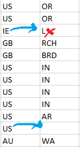

```python
# strip whitespace to lower category count
survey_data['Region'] = survey_data['Region'].str.strip()

# replace inconsistent Regions with Country Code
mask = survey_data['Region'].str.len() == 1
survey_data.loc[mask,'Region'] = survey_data.loc[mask, 'Country Code']

# replace NaN's with Country Code
mask_nan = survey_data['Region'].isna()
survey_data.loc[mask_nan,'Region'] = survey_data.loc[mask_nan, 'Country Code']
```

# Visualizing Remaining Missing Values

An abudance of missing data was noted last time in the missing data matrix. Here, we sort the values by the metadata variable "Response Status"; a categorical column telling if the survey was completed. This sorted data is then viewed in the matrix:

```
Number of entries for each category:
 Completed     198
Started       171
Terminated      1
Name: Response Status, dtype: int64

Missing Matrix:
```

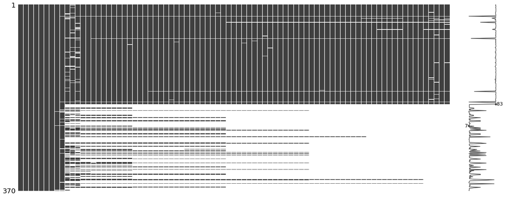

```python
import missingno as msno

# display number of entries for each category
print('Number of entries for each category:\n', survey_data['Response Status'].value_counts(), '\n\nMissing Matrix:')
# display matrix sorted by "Response Status" categories
msno.matrix(survey_data.sort_values(by='Response Status'))
```

This is telling and becomes obivous; those who did not finish the survey (Started & Terminated categories) left us with the majority of missing values. However, it can be seen that some of these are *almost* finished, while some completed surveys are almost completely missing. This will be explored further next week.

# Outputing a Spreadsheet of Progress

Python libraries support for easy storing of our dataframe to an excel file. Here the survey_data dataframe is written neatly into excel.

```python
from openpyxl import Workbook
from openpyxl.styles import Alignment, Font, Border, Side, PatternFill
from openpyxl.utils.dataframe import dataframe_to_rows

# create excel sheet
wb = Workbook()
ws = wb.active

# write dataframe into openpyxl object
survey_data = survey_data.astype('object')
for r in dataframe_to_rows(survey_data, index=False, header=True):
    ws.append(r)

# columns to widen
columns = ['J', 'K', 'L', 'M', 'N', 'O', 'P', 'Q', 'R', 'S', 'T', 'U', 'V', 'W', 'X', 'Y', 'Z', 'AA', 'AB', 'AC', 'AD', 'AE', 'AF', 'AG', 'AH', 'AI', 'AJ', 'AK',\
           'AL', 'AM', 'AN', 'AO', 'AP', 'AQ', 'AR', 'AS', 'AT', 'AU', 'AV', 'AW', 'AX', 'AY', 'AZ', 'BA', 'BB', 'BC', 'BD', 'BE', 'BF', 'BG', 'BH', 'BI', 'BJ',\
           'BK', 'BL', 'BM', 'BN', 'BO', 'BP', 'BQ', 'BR', 'BS', 'BT', 'BU', 'BV', 'BW', 'BX', 'BY', 'BZ', 'CA', 'CB', 'CC', 'CD', 'CE', 'CF', 'CG']

# widen columns
for col in columns:
    ws.column_dimensions[col].width = 24
# widen metadata columns
for col in ['A', 'B', 'C', 'E', 'D', 'H', 'I']:
    if col in ['D', 'H', 'I']:
        ws.column_dimensions[col].width = 24
    else:
        ws.column_dimensions[col].width = 15

# align and center all cells
row_num = 2
for row in ws.iter_rows():
    for cell in row:
        cell.alignment = Alignment(horizontal="center", vertical="center")
        cell.alignment =  cell.alignment.copy(wrapText=True)
        if row_num % 2 == 1:
            cell.fill = PatternFill("solid", start_color="ffffb3", end_color='ffffb3')
    ws.row_dimensions[row_num].height = 45
    row_num+=1



# for border...
thin = Side(border_style="thin", color="000000")
# loop through header

for row in ws['A1:CE1']:
  for cell in row:
    # add border and color to header cells
    cell.border = Border(top=thin, left=thin, right=thin, bottom=thin)
    cell.fill = PatternFill("solid", start_color="146e33", end_color='146e33')


wb.save(filename='output.xlsx')
```